# Weather Dataset

## Load and clear dataset

```python
import pandas as pd

# Load dataset
df = pd.read_csv('weatherHistory.csv')

# Print a concise summary of a DataFrame.
df.info()
```

```
<class 'pandas.core.frame.DataFrame'>
RangeIndex: 96453 entries, 0 to 96452
Data columns (total 12 columns):
Formatted Date              96453 non-null object
Summary                     96453 non-null object
Precip Type                 95936 non-null object
Temperature (C)             96453 non-null float64
Apparent Temperature (C)    96453 non-null float64
Humidity                    96453 non-null float64
Wind Speed (km/h)           96453 non-null float64
Wind Bearing (degrees)      96453 non-null float64
Visibility (km)             96453 non-null float64
Loud Cover                  96453 non-null float64
Pressure (millibars)        96453 non-null float64
Daily Summary               96453 non-null object
dtypes: float64(8), object(4)
memory usage: 8.8+ MB
```

### Drop rows that contain null values and columns that don't provide any kind of information

```python
#Check if we have null values
print(df.isnull().sum())

#Drop the rows where at least one element is missing
df = df.dropna()
```

```
Formatted Date                0
Summary                       0
Precip Type                 517
Temperature (C)               0
Apparent Temperature (C)      0
Humidity                      0
Wind Speed (km/h)             0
Wind Bearing (degrees)        0
Visibility (km)               0
Loud Cover                    0
Pressure (millibars)          0
Daily Summary                 0
dtype: int64
```

```python
#First observation, is that the column 'Loud Cover' has only 1 unique value, 0, so it's useless and therefore we remove it
print(df['Loud Cover'].unique())
df = df.drop(['Loud Cover'], axis=1)
```

```
[0.]
```

```python
#Print the columns of the cells that are left
df
```

|  | Formatted Date | Summary | Precip Type | Temperature (C) | Apparent Temperature (C) | Humidity | Wind Speed (km/h) | Wind Bearing (degrees) | Visibility (km) | Pressure (millibars) | Daily Summary |
| --- | --- | --- | --- | --- | --- | --- | --- | --- | --- | --- | --- |
| 0 | 2006-04-01 00:00:00.000 +0200 | Partly Cloudy | rain | 9.472222 | 7.388889 | 0.89 | 14.1197 | 251.0 | 15.8263 | 1015.13 | Partly cloudy throughout the day. |
| 1 | 2006-04-01 01:00:00.000 +0200 | Partly Cloudy | rain | 9.355556 | 7.227778 | 0.86 | 14.2646 | 259.0 | 15.8263 | 1015.63 | Partly cloudy throughout the day. |
| 2 | 2006-04-01 02:00:00.000 +0200 | Mostly Cloudy | rain | 9.377778 | 9.377778 | 0.89 | 3.9284 | 204.0 | 14.9569 | 1015.94 | Partly cloudy throughout the day. |
| 3 | 2006-04-01 03:00:00.000 +0200 | Partly Cloudy | rain | 8.288889 | 5.944444 | 0.83 | 14.1036 | 269.0 | 15.8263 | 1016.41 | Partly cloudy throughout the day. |
| 4 | 2006-04-01 04:00:00.000 +0200 | Mostly Cloudy | rain | 8.755556 | 6.977778 | 0.83 | 11.0446 | 259.0 | 15.8263 | 1016.51 | Partly cloudy throughout the day. |
| ... | ... | ... | ... | ... | ... | ... | ... | ... | ... | ... | ... |
| 96448 | 2016-09-09 19:00:00.000 +0200 | Partly Cloudy | rain | 26.016667 | 26.016667 | 0.43 | 10.9963 | 31.0 | 16.1000 | 1014.36 | Partly cloudy starting in the morning. |
| 96449 | 2016-09-09 20:00:00.000 +0200 | Partly Cloudy | rain | 24.583333 | 24.583333 | 0.48 | 10.0947 | 20.0 | 15.5526 | 1015.16 | Partly cloudy starting in the morning. |
| 96450 | 2016-09-09 21:00:00.000 +0200 | Partly Cloudy | rain | 22.038889 | 22.038889 | 0.56 | 8.9838 | 30.0 | 16.1000 | 1015.66 | Partly cloudy starting in the morning. |
| 96451 | 2016-09-09 22:00:00.000 +0200 | Partly Cloudy | rain | 21.522222 | 21.522222 | 0.60 | 10.5294 | 20.0 | 16.1000 | 1015.95 | Partly cloudy starting in the morning. |
| 96452 | 2016-09-09 23:00:00.000 +0200 | Partly Cloudy | rain | 20.438889 | 20.438889 | 0.61 | 5.8765 | 39.0 | 15.5204 | 1016.16 | Partly cloudy starting in the morning. |

95936 rows × 11 columns

## Scatterplot matrix

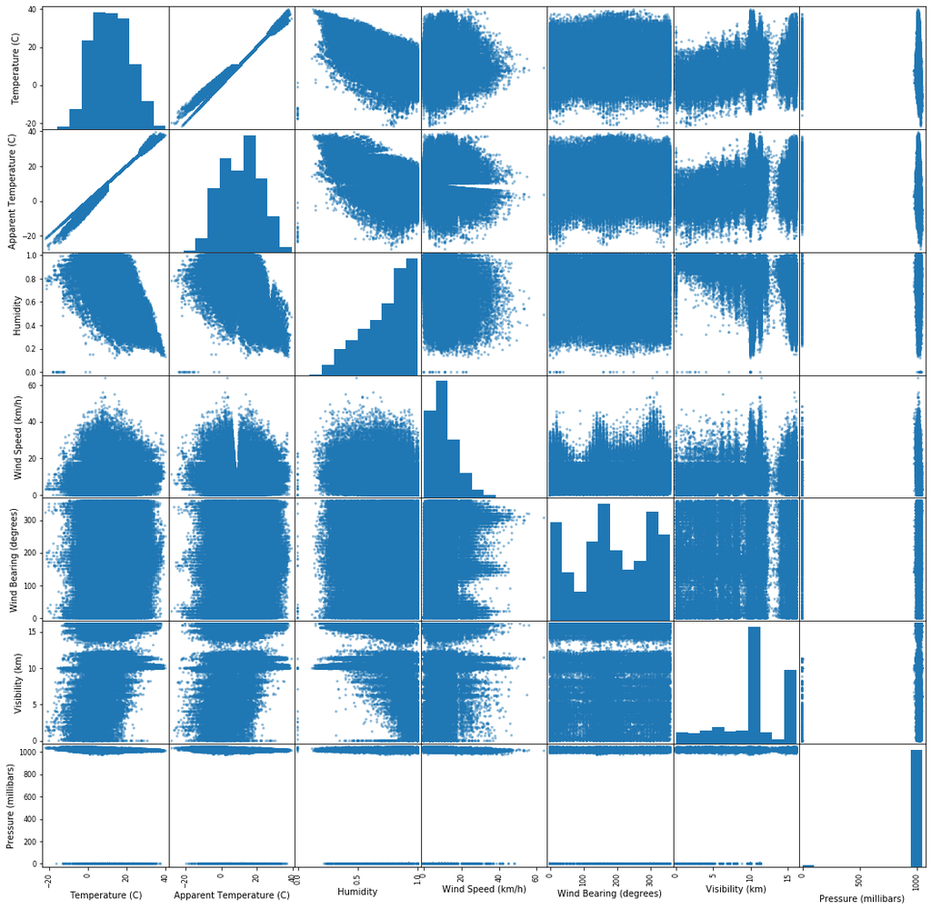

```python
import matplotlib.pyplot as plt
from pandas.plotting import scatter_matrix
scatter_matrix(df[['Temperature (C)', 'Apparent Temperature (C)', 'Humidity', 'Wind Speed (km/h)',
                  'Wind Bearing (degrees)', 'Visibility (km)', 'Pressure (millibars)']], figsize=(16,16))
plt.show()
```

### Conclusions From Scatterplot matrix

The first thing i can see, comparing the temperature and apparent temperature graphs, is that the wind speed, wind bearing(direction) and humidity affect the apparent temperature:

```
-I would expect wind speed to have a higher effect on the apparent temperature (based on human knowledge). Also because there is a gap of values in the 'Apparent Temperature/Wind speed' scatterplot matrix (the one looking like pac-man), i think that the calculation of the apparent temperature is relied on an 'if this then that' rule, making it not so scientifically correct.
-The effect of humidity is clearly visible, lower temperatures have higher humidity (negatively correlated)
-The effect of wind bearing is slightly visible.
```

The other thing i can notice, is that the temperature and the aparent temperature are about the same, but there are some slight differences in below ~+10C and above ~+30C. Specifically, below ~+10C, the apparent temperature is slightly lower than the temperature, and above ~+30C, the apparent temperature is slightly bigger than the temperature. Probably this has to do with how humans perceive very cold and very hot temperatures, or with wind speeds etc..

I also noticed that some data have pressure 0 while most of the data are between 900-1100. Wikipedia, says : "The record low is 870 mbar" so these are obviously false data, where the sensor failed to give a value. So i proceeded to a numeric analysis of the data.

```python
df.describe()
```

|  | Temperature (C) | Apparent Temperature (C) | Humidity | Wind Speed (km/h) | Wind Bearing (degrees) | Visibility (km) | Pressure (millibars) |
| --- | --- | --- | --- | --- | --- | --- | --- |
| count | 95936.000000 | 95936.000000 | 95936.000000 | 95936.000000 | 95936.000000 | 95936.000000 | 95936.000000 |
| mean | 11.940976 | 10.862531 | 0.734841 | 10.804936 | 187.518773 | 10.362402 | 1003.150038 |
| std | 9.570671 | 10.717812 | 0.195724 | 6.920727 | 107.385351 | 4.173780 | 117.276976 |
| min | -21.822222 | -27.716667 | 0.000000 | 0.000000 | 0.000000 | 0.000000 | 0.000000 |
| 25% | 4.604167 | 2.276389 | 0.600000 | 5.796000 | 116.000000 | 8.372000 | 1011.890000 |
| 50% | 12.033333 | 12.033333 | 0.780000 | 9.933700 | 180.000000 | 10.046400 | 1016.420000 |
| 75% | 18.844444 | 18.844444 | 0.890000 | 14.135800 | 290.000000 | 14.812000 | 1021.050000 |
| max | 39.905556 | 39.344444 | 1.000000 | 63.852600 | 359.000000 | 16.100000 | 1046.380000 |

We can easily see, that the error i found is not only on pressure's values. There must be false rows. Let's check:

```python
df_pressure_zero = df[df['Pressure (millibars)'] == 0]
df_pressure_zero
```

[output not shown]

#### Seems like the are no false rows.

Instead, sometimes one of the sensors is failing to read a value, while the others are working. In this point, we can decide whether to remove these rows or to keep them, depending on the purpose of our model, on the amount of data we have and if removing these rows improves the model.

## Correlation matrix

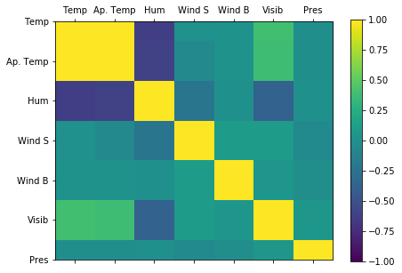

```python
import numpy as np

# Compute pairwise correlation of columns
correlations = df[['Temperature (C)', 'Apparent Temperature (C)', 'Humidity', 'Wind Speed (km/h)',
                  'Wind Bearing (degrees)', 'Visibility (km)', 'Pressure (millibars)']].corr()

# Plot correlation matrix
fig = plt.figure(figsize=(7,5))
ax = fig.add_subplot(111)
cax = ax.matshow(correlations, vmin=-1, vmax=1)
fig.colorbar(cax)
ticks = np.arange(0,7,1)
ax.set_xticks(ticks)
ax.set_yticks(ticks)
columns = ['Temp', 'Ap. Temp', 'Hum', 'Wind S', 'Wind B', 'Visib', 'Pres']
ax.set_xticklabels(columns)
ax.set_yticklabels(columns)
plt.show()
```

#### The strongest collerations i see are:

[output not shown]

## Predict temperature only from humidity data

```python
from sklearn.model_selection import train_test_split
from sklearn.metrics import mean_squared_error

# Remove a few rows that have 0 humidity (because that's not possible)
df = df[df['Humidity'] != 0]

# Split train/test set
train_set, test_set = train_test_split(df, test_size=0.2, random_state=34)
X_train = train_set['Humidity'].values.reshape(-1, 1)
y_train = train_set['Temperature (C)']
X_test = test_set['Humidity'].values.reshape(-1, 1)
y_test = test_set['Temperature (C)']

def train_and_predict(algorithm, verbose):
    model = algorithm
    model.fit(X_train, y_train)

    # Compute RMSE
    predictions = model.predict(X_test) # Predictions on the training set
    mse = mean_squared_error(y_test, predictions) # Computing MSE
    rmse = np.sqrt(mse) # Taking the root

    if verbose:
        print(rmse)
    else:
        return rmse
```

```python
from sklearn.linear_model import LinearRegression
train_and_predict(LinearRegression(), 1)
```

```
7.331607691519907
```

```python
from sklearn.linear_model import SGDRegressor
train_and_predict(SGDRegressor(max_iter=5000,penalty=None,tol=-np.infty, random_state=42), 1)
```

```
7.332758364765751
```

```python
from sklearn.neighbors import KNeighborsRegressor

# Find best value for n_neighbors
min_error=1000
best_n = 0
for ln in range(1,200):
    rmse = train_and_predict(KNeighborsRegressor(n_neighbors=ln), 0)

    if min_error>rmse:
        min_error=rmse
        best_n=ln

print("Best value for neighbours is:",best_n,"with MSE:",min_error)
```

```
Best value for neighbours is: 196 with MSE: 7.126224294168372
```

```python
from sklearn.ensemble import RandomForestRegressor

# Find best value for n_estimators
min_error=1000
best_n = 0
for ln in range(1,100):
    rmse = train_and_predict(RandomForestRegressor(n_estimators=ln), 0)

    if min_error>rmse:
        min_error=rmse
        best_n=ln

print("Best value for number of trees is:",best_n,"with MSE:",min_error)
```

```
Best value for number of trees is: 35 with MSE: 7.103128711577398
```